# ezcox: an R Package for Cox Model Batch Processing and Visualization

## Simple usage

In this section, we will show simple usage of **ezcox** by constructing single unvariable and multivariable Cox models.

### Single unvariable model

Here we simply construct a Cox model for overall survival (OS) only with `TP53`.

```r
rv <- ezcox(df, covariates = "TP53", time = "OS.time", status = "OS")
## => Processing variable TP53
## ==> Building Surv object...
## ==> Building Cox model...
## ==> Done.
rv
```

```
## # A tibble: 1 × 12
##   Variable is_control contrast_level ref_level n_contrast n_ref   beta    HR
##   <chr>    <lgl>      <chr>          <chr>          <int> <int>  <dbl> <dbl>
## 1 TP53     FALSE      TP53           TP53           10496 10496 0.0393  1.04
## # … with 4 more variables: lower_95 <dbl>, upper_95 <dbl>, p.value <dbl>,
## #   global.pval <dbl>
```

Useful information about the result model has been output as a `data.frame`.

If you just want to show a forest plot for this model, you can use the following command. You only need to change the function name!

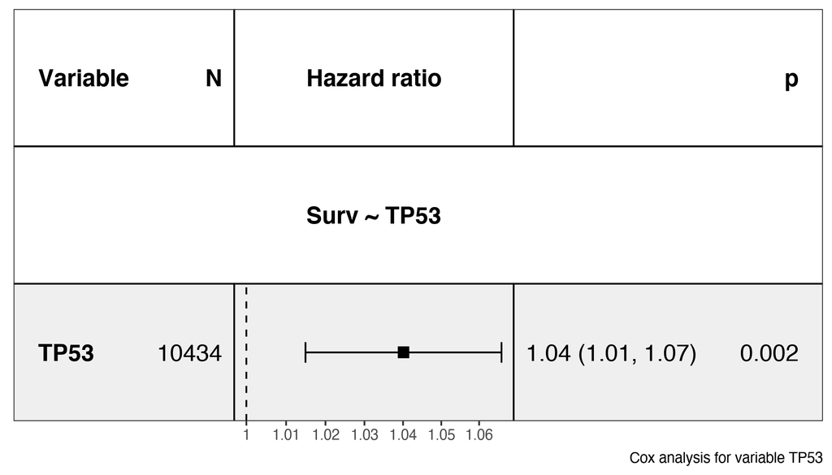

```r
show_forest(df, covariates = "TP53", time = "OS.time", status = "OS")
## => Processing variable TP53
## ==> Building Surv object...
## ==> Building Cox model...
## ==> Done.
## Resized limits to included dashed line in forest panel
```

To simplify, use:

```r
show_forest(df,
  covariates = "TP53", time = "OS.time", status = "OS",
  merge_models = TRUE, add_caption = FALSE
)
## => Processing variable TP53
## ==> Building Surv object...
## ==> Building Cox model...
## ==> Done.
## Resized limits to included dashed line in forest panel
```

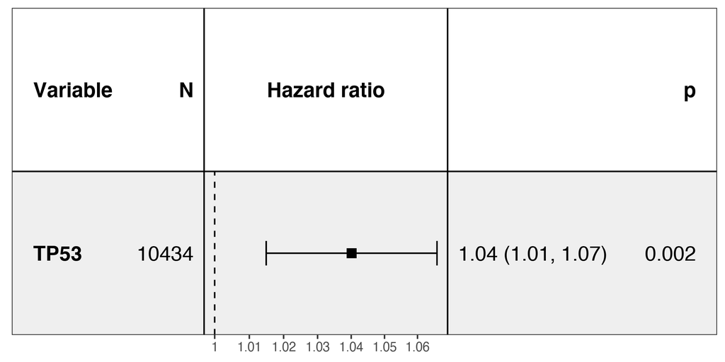

The data shows when TP53 gene expression increases, the patient would have poor clinical outcome.

Actually, you may want to obtain the model behind the plot, you can use the command to return model firstly:

```r
rv <- ezcox(df, covariates = "TP53", time = "OS.time", status = "OS", return_models = TRUE)
## => Processing variable TP53
## ==> Building Surv object...
## ==> Building Cox model...
## ==> Done.
rv
```

```
## $res
## # A tibble: 1 × 12
##   Variable is_control contrast_level ref_level n_contrast n_ref   beta    HR
##   <chr>    <lgl>      <chr>          <chr>          <int> <int>  <dbl> <dbl>
## 1 TP53     FALSE      TP53           TP53           10496 10496 0.0393  1.04
## # … with 4 more variables: lower_95 <dbl>, upper_95 <dbl>, p.value <dbl>,
## #   global.pval <dbl>
##
## $models
## # A tibble: 1 × 5
##   Variable control model_file                                      model  status
##   <chr>    <chr>   <chr>                                           <list> <lgl>
## 1 TP53     <NA>    /Volumes/Extra/R/Rtmp//RtmpCWQCzZ/ezcox/ezcox_… <coxp… TRUE
##
## attr(,"class")
## [1] "ezcox" "list"
## attr(,"controls")
## character(0)
```

Then you can get it:

```r
get_models(rv)
```

```
## $`Surv ~ TP53`
## Call:
## coxph(formula = fm, data = data)
##
##         coef exp(coef) se(coef)     z       p
## TP53 0.03933   1.04012  0.01252 3.142 0.00168
##
## Likelihood ratio test=9.88  on 1 df, p=0.001669
## n= 10434, number of events= 3251
##    (因为不存在，62个观察量被删除了)
##
## attr(,"class")
## [1] "ezcox_models" "list"
## attr(,"has_control")
## [1] FALSE
```

### Single multivariable model

It’s very easy to construct a multivariable model by introducing another parameter `controls`. For example, if we want to explore the `TP53` expression with patients’ age and clinical stage also taking into consideration.

Let’s clean the data firstly:

```r
df <- df %>%
  mutate(
    stage = case_when(
      clinical_stage %in% c("I", "Stage I", "Stage IA1", "Stage IA2", "Stage IB", "Stage IB1", "Stage IB2", "Stage IC") ~ "I",
      clinical_stage %in% c("IIa", "IIb", "Stage II", "Stage IIA", "Stage IIA1", "Stage IIA2", "Stage IIB", "Stage IIC") ~ "II",
      clinical_stage %in% c("III", "Stage III", "Stage IIIA", "Stage IIIB", "Stage IIIC", "Stage IIIC1", "Stage IIIC2") ~ "III",
      clinical_stage %in% c("IVa", "IVb", "Stage IV", "Stage IVA", "Stage IVB", "Stage IVC") ~ "IV",
      TRUE ~ NA_character_
    ),
    stage = factor(stage, levels = c("I", "II", "III", "IV"))
  )
```

```r
rv <- ezcox(df,
  covariates = "TP53", controls = c("age", "stage"),
  time = "OS.time", status = "OS", return_models = TRUE
)
## => Processing variable TP53
## ==> Building Surv object...
## ==> Building Cox model...
## ==> Done.
rv
```

```
## $res
## # A tibble: 5 × 12
##   Variable is_control contrast_level ref_level n_contrast n_ref    beta    HR
##   <chr>    <lgl>      <chr>          <chr>          <dbl> <dbl>   <dbl> <dbl>
## 1 TP53     FALSE      TP53           TP53           10496 10496 -0.0404  0.96
## 2 TP53     TRUE       age            age            10445 10445  0.022   1.02
## 3 TP53     TRUE       II             I                423   463  0.457   1.58
## 4 TP53     TRUE       III            I                711   463  1.1     3
## 5 TP53     TRUE       IV             I                445   463  1.37    3.93
## # … with 4 more variables: lower_95 <dbl>, upper_95 <dbl>, p.value <dbl>,
## #   global.pval <dbl>
##
## $models
## # A tibble: 1 × 5
##   Variable control   model_file                                    model  status
##   <chr>    <chr>     <chr>                                         <list> <lgl>
## 1 TP53     age,stage /Volumes/Extra/R/Rtmp//RtmpCWQCzZ/ezcox/ezco… <coxp… TRUE
##
## attr(,"class")
## [1] "ezcox" "list"
## attr(,"controls")
## [1] "age"   "stage"
```

The code constructed a model as below:

```r
names(get_models(rv))
```

```
## [1] "Surv ~ TP53 + age + stage"
```

For single model, we can exchange the role of covariable and control variables, they are the same model. The key point is how what we want to explore and how we treat and explain the model.

```r
# If you passing the parameters below to ezcox() will return the same model
covariates = "TP53", controls = c("age", "stage")
covariates = "age", controls = c("TP53", "stage")
covariates = "stage", controls = c("age", "TP53")
```

Still, let’s show the result more clearly with forest plot:

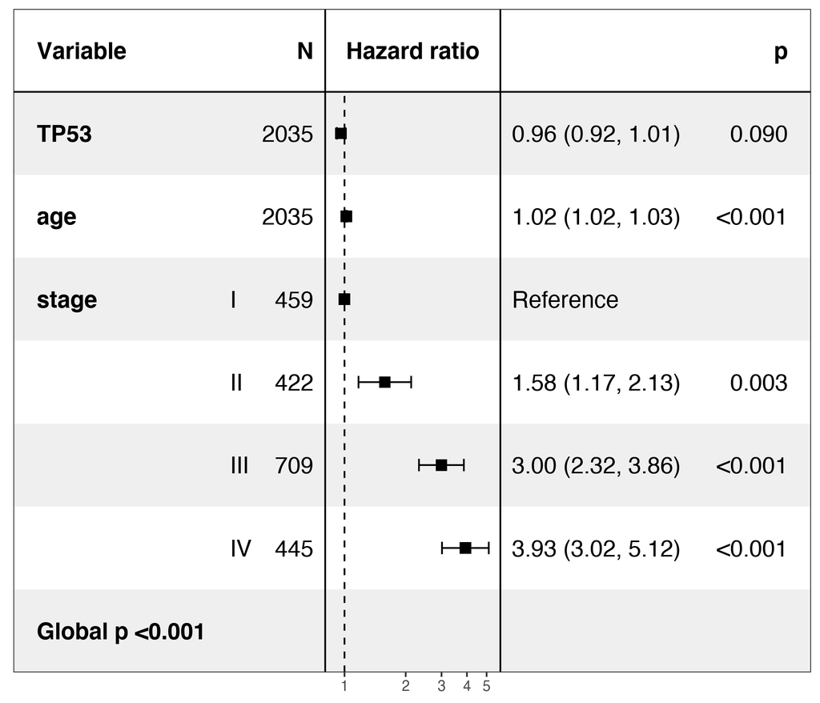

```r
show_forest(df,
  covariates = "TP53", controls = c("age", "stage"),
  time = "OS.time", status = "OS", merge_models = TRUE,
  show_global_p = "bottom", add_caption = FALSE
)
## => Processing variable TP53
## ==> Building Surv object...
## ==> Building Cox model...
## ==> Done.
## Warning in recalculate_width_panels(panel_positions, mapped_text =
## mapped_text, : Unable to resize forest panel to be smaller than its heading;
## consider a smaller text size
```

Ooops! Why TP53 has no significant association with OS when the clinical features have been included?

There are some reasons:

1. The first reason we can read from the forest plots above. TP53 is not an independent variable, it has association with patient’s age and clinical stages. You could explore this with correlation analysis and box plots.
2. In the model above, we ignored a very strong factor, i.e., “cancer type”. We already know that different tissues have different gene expression status. Actually, TP53 plays different roles in different cancer types. You can read some papers for more details.

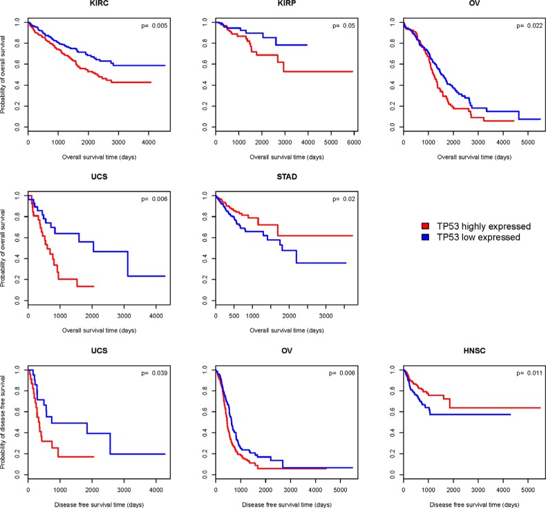

source: https://www.ncbi.nlm.nih.gov/pmc/articles/PMC5352183/

## Batch processing

Now, we are moving to the most powerful part of **ezcox**. Cox analysis is a common analysis technique to link variable to clinical outcome. In the omics era, Cox model batch processing is a basic strategy for screening clinical relevant variables, biomarker discovery and gene signature identification. However, all such analyses have been implemented with homebrew code in research community, thus lack of transparency and reproducibility. **ezcox** is born to address this issue for open science.

In batch processing, we provide execution in either sequential or parallel ways.

Considering only ~2,000 patients have stage status. The following code will only include age, cancer type, gender as control variables in the model construction, so most of the data (~10,000) can be utilized.

### Sequential execution

The only parameter we need to change is `covariates`, instead one variable, we pass a vector for batch processing.

```r
bt <- ezcox(df,
  covariates = gene_list, controls = c("age", "gender", "type"),
  time = "OS.time", status = "OS",
  keep_models = TRUE, return_models = FALSE
)
# don't return models if you have many models in processing
```

That’s it.

```r
DT::datatable(bt$res, caption = "Cox batch processing result for ~500 genes in TCGA dataset")
```

|  | Variable | is_control | contrast_level | ref_level | n_contrast | n_ref | beta | HR | lower_95 | upper_95 | p.value | global.pval |
| --- | --- | --- | --- | --- | --- | --- | --- | --- | --- | --- | --- | --- |
| 1 | TP53 | False | TP53 | TP53 | 10496 | 10496 | 0.0103 | 1.01 | 0.984 | 1.04 | 0.45 | 0 |
| 2 | TP53 | True | age | age | 10445 | 10445 | 0.0246 | 1.02 | 1.02 | 1.03 | 8.36e-59 | 0 |
| 3 | TP53 | True | MALE | FEMALE | 5228 | 5268 | 0.0619 | 1.06 | 0.981 | 1.15 | 0.137 | 0 |
| 4 | TP53 | True | BLCA | ACC | 426 | 77 | 0.334 | 1.4 | 0.926 | 2.1 | 0.111 | 0 |
| 5 | TP53 | True | BRCA | ACC | 1211 | 77 | -0.856 | 0.425 | 0.282 | 0.639 | 4.04e-05 | 0 |
| 6 | TP53 | True | CESC | ACC | 309 | 77 | -0.067 | 0.935 | 0.598 | 1.46 | 0.769 | 0 |
| 7 | TP53 | True | CHOL | ACC | 45 | 77 | 0.608 | 1.84 | 1.05 | 3.22 | 0.0334 | 0 |
| 8 | TP53 | True | COAD | ACC | 329 | 77 | -0.423 | 0.655 | 0.42 | 1.02 | 0.0622 | 0 |
| 9 | TP53 | True | DLBC | ACC | 47 | 77 | -0.809 | 0.445 | 0.209 | 0.95 | 0.0363 | 0 |
| 10 | TP53 | True | ESCA | ACC | 195 | 77 | 0.796 | 2.22 | 1.43 | 3.45 | 0.000412 | 0 |

[output cut: 19766 more lines]

```r
DT::datatable(bt$models, caption = "The models have been stored in local files")
```

|  | Variable | control | model_file |
| --- | --- | --- | --- |
| 1 | TP53 | age,gender,type | /Volumes/Extra/R/Rtmp//RtmpCWQCzZ/ezcox/ezcox_556069f20eff |
| 2 | KRAS | age,gender,type | /Volumes/Extra/R/Rtmp//RtmpCWQCzZ/ezcox/ezcox_556012b6bdb0 |
| 3 | PIK3CA | age,gender,type | /Volumes/Extra/R/Rtmp//RtmpCWQCzZ/ezcox/ezcox_55601b5f7769 |
| 4 | BRAF | age,gender,type | /Volumes/Extra/R/Rtmp//RtmpCWQCzZ/ezcox/ezcox_556018989c89 |
| 5 | LRP1B | age,gender,type | /Volumes/Extra/R/Rtmp//RtmpCWQCzZ/ezcox/ezcox_55604b4cf2fc |
| 6 | KMT2D | age,gender,type | /Volumes/Extra/R/Rtmp//RtmpCWQCzZ/ezcox/ezcox_556028e4a503 |
| 7 | APC | age,gender,type | /Volumes/Extra/R/Rtmp//RtmpCWQCzZ/ezcox/ezcox_55603b0d7cee |
| 8 | ARID1A | age,gender,type | /Volumes/Extra/R/Rtmp//RtmpCWQCzZ/ezcox/ezcox_556072850b8b |
| 9 | KMT2C | age,gender,type | /Volumes/Extra/R/Rtmp//RtmpCWQCzZ/ezcox/ezcox_55607cb90d69 |
| 10 | PTEN | age,gender,type | /Volumes/Extra/R/Rtmp//RtmpCWQCzZ/ezcox/ezcox_5560591fa877 |

[output cut: 556 more lines]

To note, we did not directly store all models from the batch processing in the result object `bt`. Instead, we store the models to local file and link it to each covariates. On the one hand, we can store the modeling result for reproducible research and avoid repetitive calculation. On the other hand, we can filter model by simply filtering the data table `bt$res` and retrieve specific models we required for downstream analysis and visualization.

### Parallel execution

For parallel execution, we only need to change the function from `ezcox()` to `ezcox_parallel()`. At default, it would use multiple sessions to process the task. `batch_size` is used to set the workload of each session.

```r
bt2 <- ezcox_parallel(df,
  covariates = gene_list, controls = c("age", "gender", "type"),
  time = "OS.time", status = "OS",
  keep_models = TRUE, return_models = FALSE, batch_size = 50
)
```

```r
all.equal(bt$res, bt2$res)
```

```
## [1] TRUE
```

### Visualization filtering

There are so many variables, we can’t visualize them in one forest plot. Next we need to filter the result before plotting.

Firstly, we quickly filter out all controls.

```r
bt3 <- filter_ezcox(bt)
```

Sort the result by `p.value` and then show it with table.

```r
bt3$res <- bt3$res %>% arrange(p.value)
DT::datatable(bt3$res, caption = "Core result from batch processing")
```

|  | Variable | is_control | contrast_level | ref_level | n_contrast | n_ref | beta | HR | lower_95 | upper_95 | p.value | global.pval |
| --- | --- | --- | --- | --- | --- | --- | --- | --- | --- | --- | --- | --- |
| 1 | LOX | False | LOX | LOX | 10496 | 10496 | 0.12 | 1.13 | 1.09 | 1.16 | 5.22e-14 | 0 |
| 2 | EHD2 | False | EHD2 | EHD2 | 10496 | 10496 | 0.114 | 1.12 | 1.09 | 1.16 | 6.31e-13 | 0 |
| 3 | FN1 | False | FN1 | FN1 | 10496 | 10496 | 0.118 | 1.12 | 1.09 | 1.16 | 7.51e-13 | 0 |
| 4 | RAC1 | False | RAC1 | RAC1 | 10496 | 10496 | 0.105 | 1.11 | 1.08 | 1.15 | 8.01e-12 | 0 |
| 5 | ABL2 | False | ABL2 | ABL2 | 10496 | 10496 | 0.102 | 1.11 | 1.07 | 1.14 | 9.76e-11 | 0 |
| 6 | MSN | False | MSN | MSN | 10496 | 10496 | 0.109 | 1.12 | 1.08 | 1.15 | 1.49e-10 | 0 |
| 7 | NRP1 | False | NRP1 | NRP1 | 10496 | 10496 | 0.101 | 1.11 | 1.07 | 1.14 | 1.55e-10 | 0 |
| 8 | EXT2 | False | EXT2 | EXT2 | 10496 | 10496 | 0.0915 | 1.1 | 1.07 | 1.13 | 2.43e-10 | 0 |
| 9 | LATS2 | False | LATS2 | LATS2 | 10496 | 10496 | 0.0948 | 1.1 | 1.07 | 1.13 | 1.28e-09 | 0 |
| 10 | COL1A1 | False | COL1A1 | COL1A1 | 10496 | 10496 | 0.107 | 1.11 | 1.08 | 1.15 | 1.44e-09 | 0 |

[output cut: 556 more lines]

How many variables are statistical significant?

```r
bt3$res %>%
  filter(p.value < 0.05) %>%
  nrow()
```

```
## [1] 248
```

That’s so many. In practice, we generally limit the final gene number <10. So for illustration, here we just keep the top ten.

```r
mds <- get_models(bt3, variables = bt3$res$Variable[1:10])
```

```r
show_models(mds[1:2],
  format_options = forestmodel::forest_model_format_options(point_size = 2)
)
```

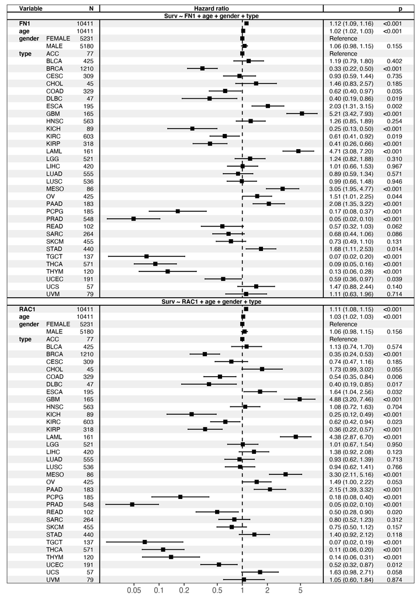

The plot is very big, such figure is only suitable for one or two target variables.

If we want to focus the gene list and include all of them in such a plot, how could we do that?

```r
show_models(
  mds,
  merge_models = TRUE,
  drop_controls = TRUE
)
## covariates=NULL but drop_controls=TRUE, detecting controls...
## Yes. Setting variables to keep...
## Done.
## Resized limits to included dashed line in forest panel
```

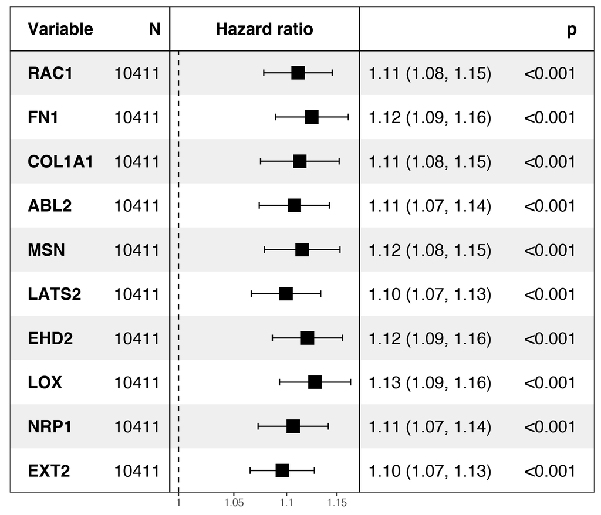